# HW2

#### 106060000 XXX

## Question 1

### Result

```python
import random

number = random.randint(1,100)
guess = 0
count = 0

while guess != number and guess != "exit":
    guess = input("What's your guess?")

    if guess == "exit":
        break

    guess = int(guess)
    count += 1

    if guess < number:
        print("Too low!")
    elif guess > number:
        print("Too high!")
    else:
        print("You got it!")
        print("And it only took you",count,"tries!")
```

```
What's your guess?50
Too low!
What's your guess?80
Too high!
What's your guess?70
Too high!
What's your guess?65
Too low!
```

## Question 2

### Result

```
negative numbers: 21
```

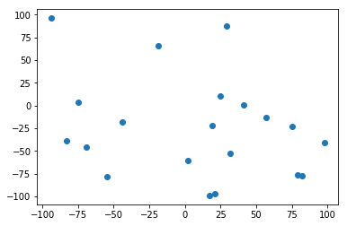

```python
import csv
import numpy as np
import matplotlib.pyplot as plt
B=[]
num_2=0
f = open('data.csv', 'r')
file_read=csv.reader(f)
for row in file_read :
    B.append(row)
f.close()
B = np.array(B,dtype = float)

C=np.where(B < 0, 1, 0)
num=np.sum(C)

for i in range(2):
    for j in range(20):
        if (B[i,j]<0):
            num_2=num_2+1
        #print(B[i,j])


print("negative numbers:",num)

[X,Y]=np.vsplit(B, 2)
plt.scatter(X,Y)
```